# ggvolcano

Yurii Chinenov

April 13, 2017

## ggvolcano

*ggvolcano* produces “volcano”" plots ($-log_{10}(p value)$ versus $-log_2(fold change)$) that is commonly used to visualize differentially expressed genes in a two group comparison. *ggvolcano* is a *ggplot*-based function. Besides a basic volcano plot with highlights “significant” diferentially-expressed genes based on user-supplied fold change and p values cutoffs, *ggvolcano* also highlights and labels additional user-supplied gene sets. `ggvolcano` relies on *ggrepel* package by Kamil Slowikowski to perform gene labeling. (ggrepel: Repulsive Text and Label Geoms for ‘ggplot2’. R package version 0.6.5. https://CRAN.R-project.org/package=ggrepel)

## Usage

```
ggvolcano (gene.id=NULL, p.val=NULL, fold.c=NULL, labels="none", de.l=list(),
           top.list=NULL, cutoff.p=0.01, cutoff.fc=2, logfold.c=T, FDR=T, binhex=F)
```

### Arguments

`gene.id` A vector of gene names

`p.val` A vector of *p* values

`fold.c` A vector of fold changes

`de.l` A vector or a list of vectors with gene names that will be shown on the plot as colored circles; when no names supplied genes will be colored  
according to p value/fold change cur offs. Each element of the list `de.l` will have unique color.

`top.list` The number of top genes in each gene set in `de.l` that will be labeled, could be combined with user supplied `label` or `label="auto"`

`cutoff.p` *p* value cut off. By default cutoff.p=0.01

`cutoff.fc` fold change cutoff. By default cutoff.fc = 2

`logfold.c` a logical value indicating whether to Log2 transform fold fold change values.By default `logfold.c=TRUE`

`FDR` a logical value indicating whether *p* values need to be adjusted for multiple comparison. By default `FDR=TRUE`, otherwise `p.addjust()` will be applied with `method="fdr"`

`binhex` a logical value indicating whether to bin nearby data points to avoid overplotting. By default `binhex=FALSE`. When `binhex=T` ’ggplot2 geom_hex` will be used to decrease the number of ploted objects

### Values

#### `gene.id`

A character vector.

```r
library(readr)
toptag1_2 <- read_csv ("toptag1_2.csv")
```

```
##  chr [1:10523] "Igsf9" "Ifi202b" "Gas2l3" "Ccl9" "Igf1" ...
```

All numeric IDs (e.g. ENTREZID) will be coersed to characters.

#### `p.val`

A numeric vector of *p* values or adjusted *p* values, for example:

```
##  num [1:10523] 5.29e-07 9.39e-07 1.39e-06 2.37e-06 4.81e-06 ...
```

#### `fold.c`

A numeric vector of fold changes

```
##  num [1:10523] -5.26 9.37 2.88 3.59 2.96 ...
```

#### Basic volcano plot

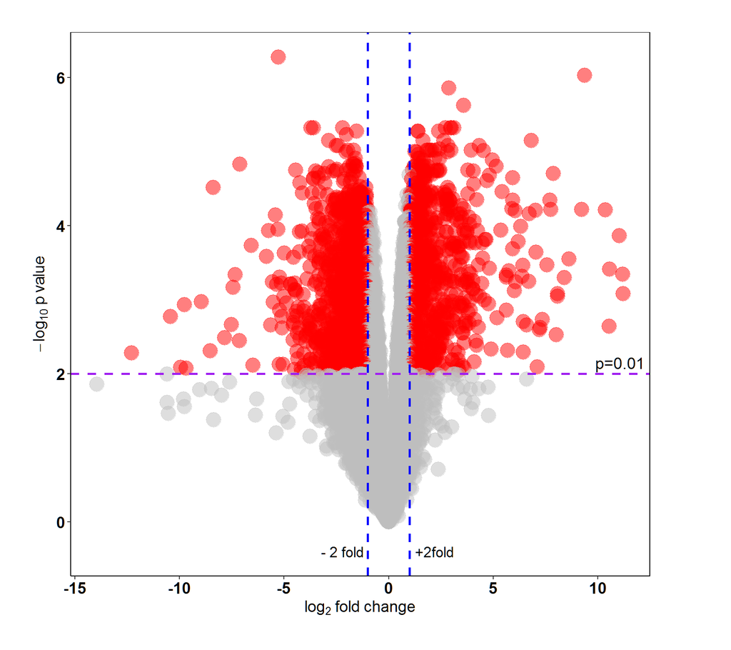

```r
ggvolcano (
  gene.id=toptag1_2$genes,
  p.val=toptag1_2$FDR,
  fold.c=toptag1_2$Fold.c,
  labels="none",
  de.l=list(),
  top.list=NULL,
  cutoff.p=0.01,
  cutoff.fc=2,
  logfold.c=T,
  FDR=T,
  binhex=F)
```

#### A volcano plot with automatic labeling and dot bining:

`binhex=T,labels="auto`

To reduce the number of plotted objects *ggvolcano* optionaly maps datapoint to hexagonal bins using `geom_hex`. All bins are intentionally colored uniformly gray rather than based on point density as I did not consider this information particularly relevant.

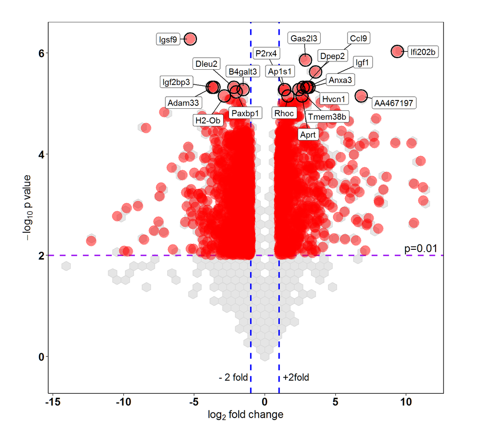

```r
ggvolcano (
  gene.id=toptag1_2$genes,
  p.val=toptag1_2$FDR,
  fold.c=toptag1_2$Fold.c,
  labels="auto",
  de.l=list(),
  top.list=NULL,
  cutoff.p=0.01,
  cutoff.fc=2,
  logfold.c=T,
  FDR=T,
  binhex=T)
```

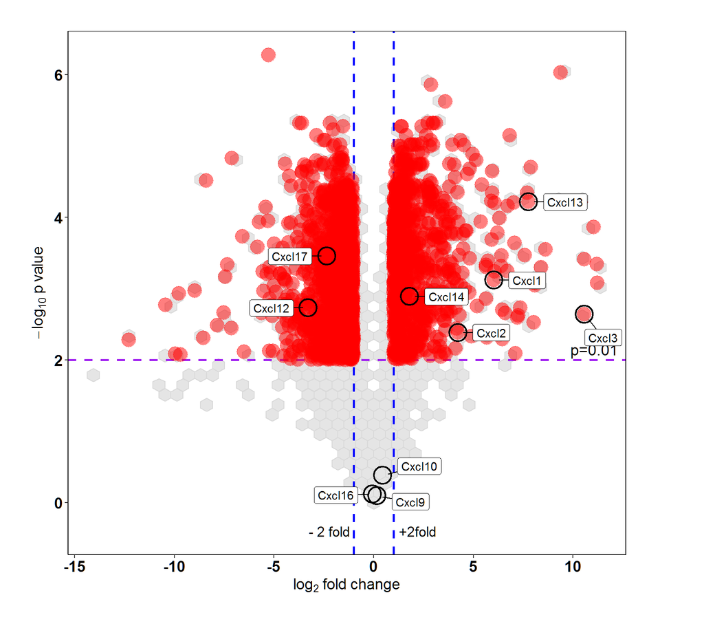

```r
ggvolcano (
  gene.id=toptag1_2$genes,
  p.val=toptag1_2$FDR,
  fold.c=toptag1_2$Fold.c,
  labels= toptag1_2$genes[grep("^Cxcl",toptag1_2$genes)],
  de.l=list(),
  top.list=NULL,
  cutoff.p=0.01,
  cutoff.fc=2,
  logfold.c=T,
  FDR=T,
  binhex=T)
```

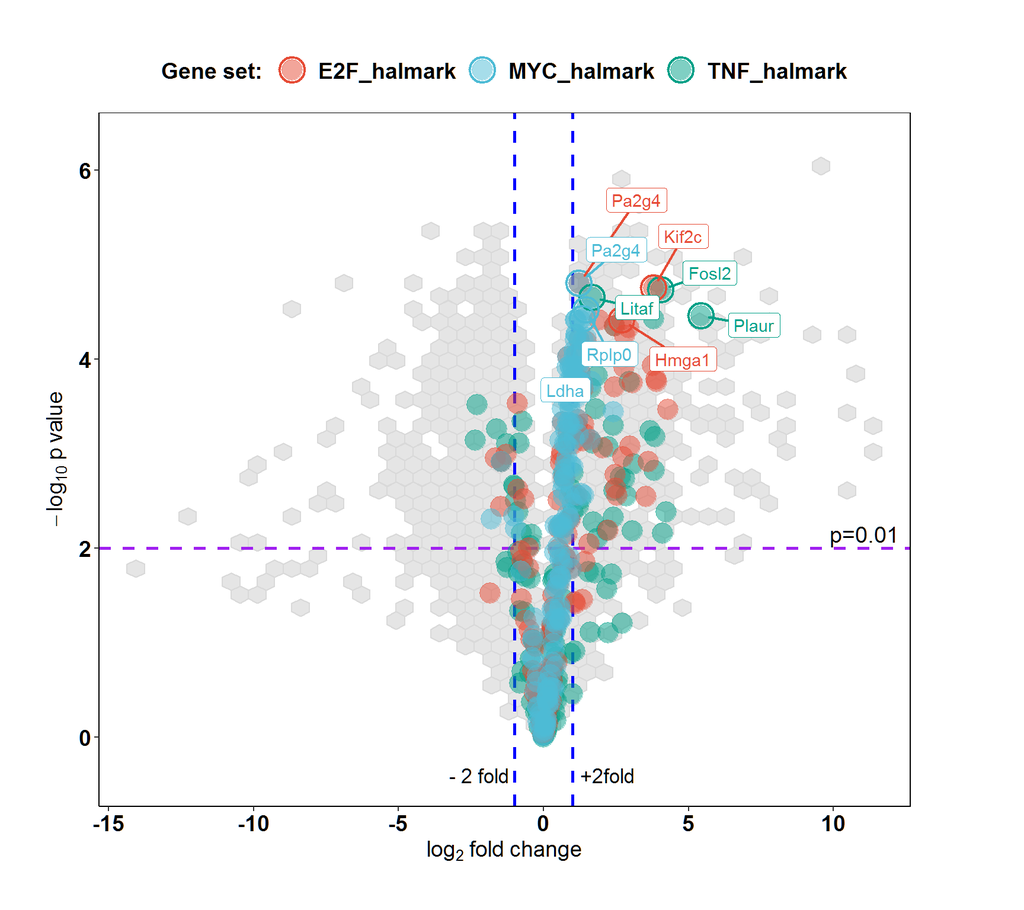

```r
ggvolcano (
  gene.id=toptag1_2$genes,
  p.val=toptag1_2$FDR,
  fold.c=toptag1_2$Fold.c,
  labels="none",
  de.l=list(TNF_halmark,E2F_halmark,MYC_halmark),
  top.list=3,
  cutoff.p=0.01,
  cutoff.fc=2,
  logfold.c=T,
  FDR=T,
  binhex=T)
```

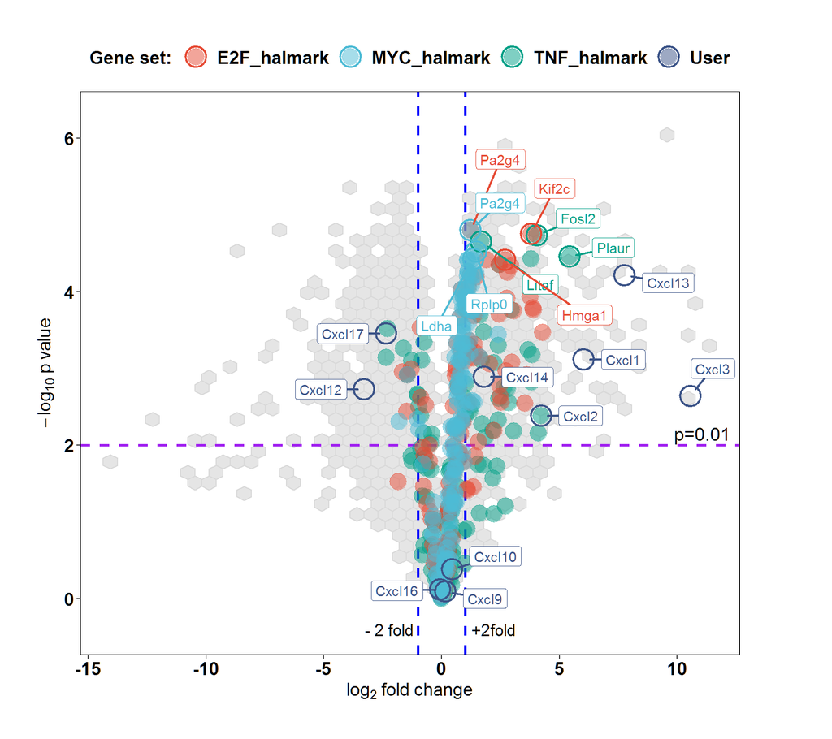

```r
ggvolcano (
  gene.id=toptag1_2$genes,
  p.val=toptag1_2$FDR,
  fold.c=toptag1_2$Fold.c,
  labels=toptag1_2$genes[grep("^Cxcl",toptag1_2$genes)],
  de.l=list(TNF_halmark,E2F_halmark,MYC_halmark),
  top.list=3,
  cutoff.p=0.01,
  cutoff.fc=2,
  logfold.c=T,
  FDR=T,
  binhex=T)
```

#### Same as above but all data points shown

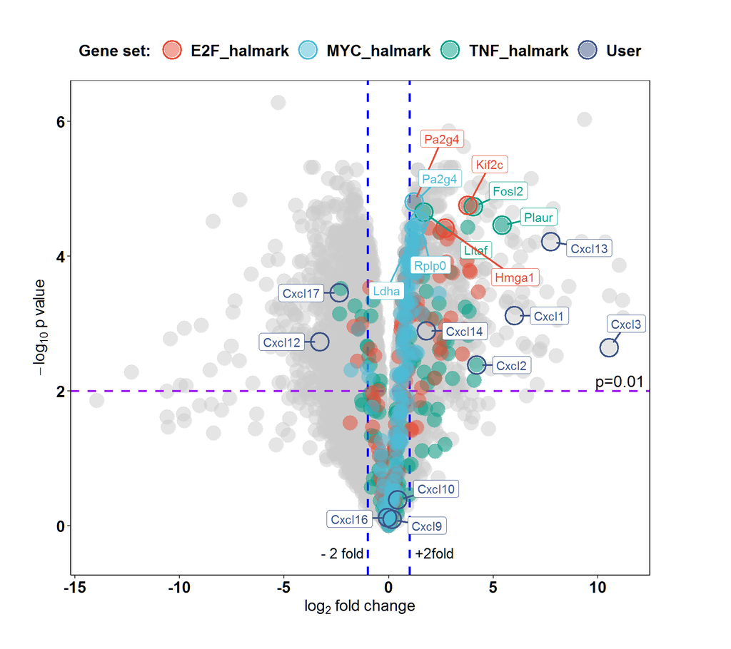

```r
ggvolcano (
  gene.id=toptag1_2$genes,
  p.val=toptag1_2$FDR,
  fold.c=toptag1_2$Fold.c,
  labels=toptag1_2$genes[grep("^Cxcl",toptag1_2$genes)],
  de.l=list(TNF_halmark,E2F_halmark,MYC_halmark),
  top.list=3,
  cutoff.p=0.01,
  cutoff.fc=2,
  logfold.c=T,
  FDR=T,
  binhex=F)
```